# Wolt_Data_Analysis

Nicholas Lim

2025-04-01

# Introduction

This analysis explores Wolt user data from Sep 2019 to Oct 2020, focusing on purchasing behavior, device usage, country-level metrics, store types, and time to first purchase. This R Markdown file is designed to be knitted into an HTML report, combining code, results, and insights for easy review.

# Load Data

```r
data <- read.csv("Wolt_dataset.csv") # Please set working directory manually if dataset does not load (e.g., `setwd("~/Documents/Wolt_dataset")` in R, or in RStudio: Session > Set Working Directory > To Source File Location).
```

# Data Exploration

```r
summary(data)
```

```
##  REGISTRATION_DATE  REGISTRATION_COUNTRY PURCHASE_COUNT
##  Length:21983       Length:21983         Min.   :  0.000
##  Class :character   Class :character     1st Qu.:  0.000
##  Mode  :character   Mode  :character     Median :  1.000
##                                          Mean   :  3.345
##                                          3rd Qu.:  3.000
##                                          Max.   :320.000
##
##  PURCHASE_COUNT_DELIVERY PURCHASE_COUNT_TAKEAWAY FIRST_PURCHASE_DAY
##  Min.   :  0.000         Min.   : 0.000          Length:21983
##  1st Qu.:  1.000         1st Qu.: 0.000          Class :character
##  Median :  2.000         Median : 0.000          Mode  :character
##  Mean   :  5.742         Mean   : 0.372
##  3rd Qu.:  6.000         3rd Qu.: 0.000
##  Max.   :320.000         Max.   :44.000
##  NA's   :9955            NA's   :9955
##  LAST_PURCHASE_DAY     USER_ID      BREAKFAST_PURCHASES LUNCH_PURCHASES
##  Length:21983       Min.   :    1   Min.   : 0.000      Min.   :  0.000
##  Class :character   1st Qu.: 5496   1st Qu.: 0.000      1st Qu.:  0.000
##  Mode  :character   Median :10992   Median : 0.000      Median :  1.000
##                     Mean   :10992   Mean   : 0.194      Mean   :  2.375
##                     3rd Qu.:16488   3rd Qu.: 0.000      3rd Qu.:  2.000
##                     Max.   :21983   Max.   :52.000      Max.   :171.000
##                                     NA's   :9955        NA's   :9955
##  EVENING_PURCHASES DINNER_PURCHASES  LATE_NIGHT_PURCHASES TOTAL_PURCHASES_EUR
##  Min.   : 0.000    Min.   :  0.000   Min.   :0            Min.   :   1.012
##  1st Qu.: 0.000    1st Qu.:  0.000   1st Qu.:0            1st Qu.:  32.384
##  Median : 0.000    Median :  1.000   Median :0            Median :  75.900
##  Mean   : 0.493    Mean   :  3.029   Mean   :0            Mean   : 176.210
##  3rd Qu.: 0.000    3rd Qu.:  3.000   3rd Qu.:0            3rd Qu.: 196.328
##  Max.   :71.000    Max.   :104.000   Max.   :0            Max.   :7979.620
##  NA's   :9955      NA's   :9955      NA's   :9955         NA's   :9955
##  DISTINCT_PURCHASE_VENUE_COUNT MIN_PURCHASE_VALUE_EUR MAX_PURCHASE_VALUE_EUR
##  Min.   : 1.00                 Min.   :  0.00         Min.   :   1.016
##  1st Qu.: 1.00                 1st Qu.: 14.20         1st Qu.:  23.368
##  Median : 2.00                 Median : 19.27         Median :  35.560
##  Mean   : 3.32                 Mean   : 24.43         Mean   :  42.068
##  3rd Qu.: 4.00                 3rd Qu.: 29.41         3rd Qu.:  51.816
##  Max.   :71.00                 Max.   :659.10         Max.   :3048.000
##  NA's   :9955                  NA's   :9955           NA's   :9955
```

[output cut: 25 more lines]

```
##  Min.   :  0.00             Min.   :  0.00
##  1st Qu.: 18.00             1st Qu.: 10.00
##  Median : 39.50             Median : 25.00
##  Mean   : 64.29             Mean   : 55.79
##  3rd Qu.: 81.00             3rd Qu.: 68.25
##  Max.   :421.00             Max.   :421.00
##  NA's   :14151              NA's   :14151
##  AVERAGE_DELIVERY_DISTANCE_KMS PURCHASE_COUNT_BY_STORE_TYPE
##  Min.   : 0.002                Length:21983
##  1st Qu.: 2.950                Class :character
##  Median : 5.928                Mode  :character
##  Mean   : 5.961
##  3rd Qu.: 8.978
##  Max.   :11.999
##  NA's   :9955
```

```r
str(data)
```

```
## 'data.frame':    21983 obs. of  30 variables:
##  $ REGISTRATION_DATE                      : chr  "2019-09-01 00:00:00.000" "2019-09-01 00:00:00.000" "2019-09-01 00:00:00.000" "2019-09-01 00:00:00.000" ...
##  $ REGISTRATION_COUNTRY                   : chr  "DNK" "FIN" "DNK" "FIN" ...
##  $ PURCHASE_COUNT                         : int  0 1 19 0 0 0 0 1 0 0 ...
##  $ PURCHASE_COUNT_DELIVERY                : int  NA 1 19 NA NA NA NA 1 NA NA ...
##  $ PURCHASE_COUNT_TAKEAWAY                : int  NA 0 0 NA NA NA NA 0 NA NA ...
##  $ FIRST_PURCHASE_DAY                     : chr  "" "2020-09-02 00:00:00.000" "2019-12-10 00:00:00.000" "" ...
##  $ LAST_PURCHASE_DAY                      : chr  "" "2020-09-02 00:00:00.000" "2020-05-25 00:00:00.000" "" ...
##  $ USER_ID                                : int  1 2 3 4 5 6 7 8 9 10 ...
##  $ BREAKFAST_PURCHASES                    : int  NA 0 0 NA NA NA NA 0 NA NA ...
##  $ LUNCH_PURCHASES                        : int  NA 1 4 NA NA NA NA 0 NA NA ...
##  $ EVENING_PURCHASES                      : int  NA 0 1 NA NA NA NA 1 NA NA ...
##  $ DINNER_PURCHASES                       : int  NA 0 14 NA NA NA NA 0 NA NA ...
##  $ LATE_NIGHT_PURCHASES                   : int  NA 0 0 NA NA NA NA 0 NA NA ...
##  $ TOTAL_PURCHASES_EUR                    : num  NA 38.5 631.5 NA NA ...
```

[output cut: 16 more lines]

# Data Cleaning & Preprocessing

- Converted date columns (`REGISTRATION_DATE`, `FIRST_PURCHASE_DAY`, `LAST_PURCHASE_DAY`) to datetime.
- Converted categorical columns (`REGISTRATION_COUNTRY`, `PREFERRED_DEVICE`, `USER_ID`, `MOST_COMMON_WEEKDAY_TO_PURCHASE`) to factors, with weekday labels for interpretability.
- Transformed `PURCHASE_COUNT_BY_STORE_TYPE` into wide-format by parsing JSON-like strings.

```r
# Change data types fit for analysis
data <- data %>%
  mutate(
    REGISTRATION_DATE = ymd_hms(REGISTRATION_DATE),
    FIRST_PURCHASE_DAY = ymd_hms(FIRST_PURCHASE_DAY),
    LAST_PURCHASE_DAY = ymd_hms(LAST_PURCHASE_DAY),
    REGISTRATION_COUNTRY = factor(REGISTRATION_COUNTRY)
  )

data$USER_ID <- as.factor(data$USER_ID)
data$PREFERRED_DEVICE <- as.factor(data$PREFERRED_DEVICE)

# Convert MOST_COMMON_WEEKDAY_TO_PURCHASE inputs to labeled form,
# to enhance interpretability
data$MOST_COMMON_WEEKDAY_TO_PURCHASE <- as.factor(data$MOST_COMMON_WEEKDAY_TO_PURCHASE)
levels(data$MOST_COMMON_WEEKDAY_TO_PURCHASE) <- c("Monday", "Tuesday", "Wednesday", "Thursday", "Friday", "Saturday", "Sunday")

## Transform PURCHASE_COUNT_BY_STORE_TYPE inputs in wide-format dataframe suitable for numerical analysis
## Parse the JSON-like strings in PURCHASE_COUNT_BY_STORE_TYPE
data$PURCHASE_COUNT_BY_STORE_TYPE[data$PURCHASE_COUNT_BY_STORE_TYPE == ""] <- NA
data$PURCHASE_COUNT_BY_STORE_TYPE <- lapply(data$PURCHASE_COUNT_BY_STORE_TYPE, function(x) {
  if (is.na(x)) return(NA)
  fromJSON(x)
})

## Extract the store types (keys) from one non-NA entry to determine the column names
store_types <- names(data$PURCHASE_COUNT_BY_STORE_TYPE[!is.na(data$PURCHASE_COUNT_BY_STORE_TYPE)][[1]])

## Create new columns for each store type
for (store_type in store_types) {
  # Replace spaces and special characters in column names to make them valid in R
  col_name <- gsub(" ", "_", store_type)  # Replace spaces with underscores
  col_name <- gsub("[^[:alnum:]_]", "", col_name)  # Remove any other special characters
  data[[col_name]] <- sapply(data$PURCHASE_COUNT_BY_STORE_TYPE, function(x) {
    if (!is.list(x)) return(NA)  # If x is not a list (i.e., it's NA), return NA
    x[[store_type]]
  })
}

## Remove the original PURCHASE_COUNT_BY_STORE_TYPE column
data$PURCHASE_COUNT_BY_STORE_TYPE <- NULL

# Rename data into user_level_data
user_level_data <- data

# Verify Changes
str(user_level_data)
```

```
## 'data.frame':    21983 obs. of  34 variables:
##  $ REGISTRATION_DATE                      : POSIXct, format: "2019-09-01" "2019-09-01" ...
##  $ REGISTRATION_COUNTRY                   : Factor w/ 59 levels "ARE","AUS","AUT",..: 15 18 15 18 24 18 15 18 18 18 ...
##  $ PURCHASE_COUNT                         : int  0 1 19 0 0 0 0 1 0 0 ...
##  $ PURCHASE_COUNT_DELIVERY                : int  NA 1 19 NA NA NA NA 1 NA NA ...
##  $ PURCHASE_COUNT_TAKEAWAY                : int  NA 0 0 NA NA NA NA 0 NA NA ...
##  $ FIRST_PURCHASE_DAY                     : POSIXct, format: NA "2020-09-02" ...
##  $ LAST_PURCHASE_DAY                      : POSIXct, format: NA "2020-09-02" ...
##  $ USER_ID                                : Factor w/ 21983 levels "1","2","3","4",..: 1 2 3 4 5 6 7 8 9 10 ...
##  $ BREAKFAST_PURCHASES                    : int  NA 0 0 NA NA NA NA 0 NA NA ...
##  $ LUNCH_PURCHASES                        : int  NA 1 4 NA NA NA NA 0 NA NA ...
##  $ EVENING_PURCHASES                      : int  NA 0 1 NA NA NA NA 1 NA NA ...
##  $ DINNER_PURCHASES                       : int  NA 0 14 NA NA NA NA 0 NA NA ...
##  $ LATE_NIGHT_PURCHASES                   : int  NA 0 0 NA NA NA NA 0 NA NA ...
##  $ TOTAL_PURCHASES_EUR                    : num  NA 38.5 631.5 NA NA ...
```

[output cut: 20 more lines]

# Exploratory Data Analysis

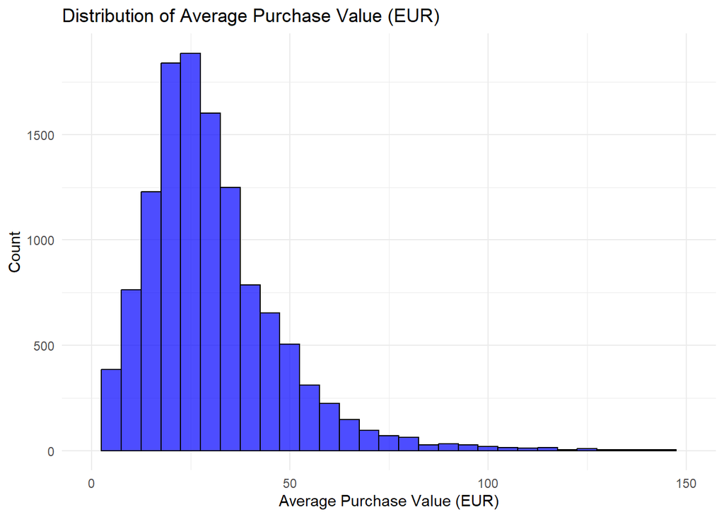

```r
ggplot(user_level_data, aes(x = AVG_PURCHASE_VALUE_EUR)) +
  geom_histogram(binwidth = 5, fill = "blue", color = "black", alpha = 0.7) +
  scale_x_continuous(limits = c(0, 150)) +
  labs(
    title = "Distribution of Average Purchase Value (EUR)",
    x = "Average Purchase Value (EUR)",
    y = "Count"
  ) +
  theme_minimal()
```

## Insight

- Majority of users spent under €50

# 1) Exploring relationship between Preferred Device & Purchases based on Device (user-level analysis)

# Proportion of Users by Preferred Device

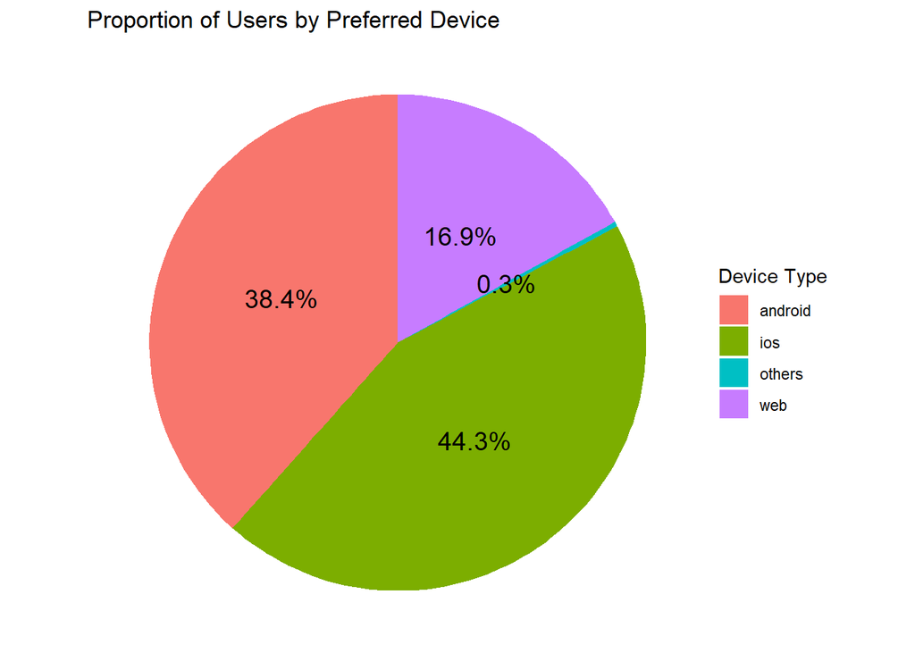

```r
# Replace empty strings in PREFERRED_DEVICE with "Others"
user_level_data <- user_level_data %>%
  mutate(PREFERRED_DEVICE = if_else(PREFERRED_DEVICE == "", "others", PREFERRED_DEVICE))

# Calculate counts and percentages for PREFERRED_DEVICE
device_counts <- user_level_data %>%
  count(PREFERRED_DEVICE, name = "n") %>%
  mutate(Percentage = n / sum(n) * 100,
         Label = paste0(round(Percentage, 1), "%"))

# Create the pie chart with percentage labels
ggplot(device_counts, aes(x = "", y = n, fill = PREFERRED_DEVICE)) +
  geom_bar(stat = "identity", width = 1) +
  coord_polar("y", start = 0) +
  geom_text(aes(label = Label),
            position = position_stack(vjust = 0.5),
            size = 5) +
  labs(title = "Proportion of Users by Preferred Device", fill = "Device Type") +
  theme_void()
```

## Insights

- 44.3% of users use IOS devices.
- 38.4% of users use Android devices.
- 16.9% of users use web devices (PC).
- 0.3% of users use other devices.

# Exploring relationship between Preferred Device and IOS/Web/Android Purchases

```r
# Create a pivot table of PREFERRED_DEVICE against IOS_PURCHASES, WEB_PURCHASES, and ANDROID_PURCHASES
pivot_table <- user_level_data %>%
  # Replace NA in purchase columns with 0 for summation
  mutate(
    IOS_PURCHASES = if_else(is.na(IOS_PURCHASES), 0, IOS_PURCHASES),
    WEB_PURCHASES = if_else(is.na(WEB_PURCHASES), 0, WEB_PURCHASES),
    ANDROID_PURCHASES = if_else(is.na(ANDROID_PURCHASES), 0, ANDROID_PURCHASES)
  ) %>%
  # Group by PREFERRED_DEVICE
  group_by(PREFERRED_DEVICE) %>%
  summarise(
    User_Count = n(),  # Number of users in each PREFERRED_DEVICE category
    Total_IOS_Purchases = sum(IOS_PURCHASES),  # Total iOS purchases
    Total_Web_Purchases = sum(WEB_PURCHASES),  # Total web purchases
    Total_Android_Purchases = sum(ANDROID_PURCHASES)  # Total Android purchases
  ) %>%
  # Arrange by User_Count in descending order
  arrange(desc(User_Count))

# Calculate grand totals for all columns
grand_totals <- pivot_table %>%
  summarise(
    PREFERRED_DEVICE = "Grand Total",
    User_Count = sum(User_Count),
    Total_IOS_Purchases = sum(Total_IOS_Purchases),
    Total_Web_Purchases = sum(Total_Web_Purchases),
    Total_Android_Purchases = sum(Total_Android_Purchases)
  )

# Combine the pivot table with the grand totals
pivot_table_with_totals <- bind_rows(
  pivot_table,
  grand_totals
)

# Display the pivot table with grand totals
print(pivot_table_with_totals)
```

```
## # A tibble: 5 × 5
##   PREFERRED_DEVICE User_Count Total_IOS_Purchases Total_Web_Purchases
##   <chr>                 <int>               <dbl>               <dbl>
## 1 ios                    9747               30019                1134
## 2 android                8448                 934                 983
## 3 web                    3715                3934               10590
## 4 others                   73                   0                   1
## 5 Grand Total           21983               34887               12708
## # ℹ 1 more variable: Total_Android_Purchases <dbl>
```

## Insights

Device Loyalty:

- iOS: (30019/(30019+1134+563)) * 100 = 94.6% of IOS Users made purchases on their preferred device.
- Android: (22967/(22967+934+983) * 100 = 92.3% of Android Users made purchases on their preferred device.
- Web: (10590/(10590+3934+2416)) * 100 = 62.5% of Web Users made purchases on their preferred device.

Cross-Device Purchasing:

- Web Users are most likely to make cross-device purchases, with 3,934 iOS purchases and 2,416 Android purchases. This suggests that the web platform might be a secondary choice for users who primarily use mobile devices.
- iOS and Android users show minimal cross-device purchasing, with only about 5-7% of their purchases on non-preferred devices.

Purchasing Activity:

## Potential Data Quality Issue

- Cross-device Purchases: iOS and Android are competing platforms, it is usual to have iOS users to have 563 Android purchases and for android users to have 934 iOS purchases. This could indicate multi-device ownership or data inconsistencies.

## Suggestion

Device Targeting:

- iOS and Android users are highly loyal to their preferred devices, so marketing efforts should focus on optimizing the mobile experience for these platforms.

Cross-Device Strategy:

- The small but notable cross-device purchasing (e.g., iOS users on web, Android users on iOS) suggests that some users are comfortable using multiple devices. Offering seamless cross-device experiences (e.g., synced accounts, consistent UI) could encourage more purchases.

# 2) Exploring Country-level Purchase Metrics (user-level analysis)

# User purchase metrics by country

```r
# Define store type columns
store_types <- c("General_merchandise", "Grocery", "Pet_supplies", "Restaurant", "Retail_store")

# Summarize purchase data by REGISTRATION_COUNTRY for purchasing users only
user_purchases_by_country_summary <- user_level_data %>%
  # Filter for purchasing users only (users with at least one purchase in store types)
  filter(rowSums(select(., all_of(store_types))) > 0) %>%
  group_by(REGISTRATION_COUNTRY) %>%
  summarise(
    Count = n(),  # Number of purchasing users in each country
    Total_Purchase_EUR = sum(TOTAL_PURCHASES_EUR, na.rm = TRUE),
    Average_Purchase_Value_EUR = mean(AVG_PURCHASE_VALUE_EUR, na.rm = TRUE),
    Breakfast_Purchases = sum(BREAKFAST_PURCHASES, na.rm = TRUE),
    Lunch_Purchases = sum(LUNCH_PURCHASES, na.rm = TRUE),
    Dinner_Purchases = sum(DINNER_PURCHASES, na.rm = TRUE),
    Evening_Purchases = sum(EVENING_PURCHASES, na.rm = TRUE),
    Late_Night_Purchases = sum(LATE_NIGHT_PURCHASES, na.rm = TRUE),
    Valid_Payment_Method_True = sum(USER_HAS_VALID_PAYMENT_METHOD == TRUE), # Count users with valid payment method
    Valid_Payment_Method_False = sum(USER_HAS_VALID_PAYMENT_METHOD == FALSE) # Count users without valid payment method
  ) %>%
  filter(Total_Purchase_EUR > 0) %>%  # Filter out rows where Total_Purchase_EUR = 0
  arrange(desc(Total_Purchase_EUR))

# Calculate grand totals for all columns
grand_totals <- user_purchases_by_country_summary %>%
  summarise(
    REGISTRATION_COUNTRY = "Grand Total",
    Count = sum(Count),
    Total_Purchase_EUR = sum(Total_Purchase_EUR),
    Average_Purchase_Value_EUR = with(., weighted.mean(Average_Purchase_Value_EUR, Count, na.rm = TRUE)),
    Breakfast_Purchases = sum(Breakfast_Purchases),
    Lunch_Purchases = sum(Lunch_Purchases),
    Dinner_Purchases = sum(Dinner_Purchases),
    Evening_Purchases = sum(Evening_Purchases),
    Late_Night_Purchases = sum(Late_Night_Purchases),
    Valid_Payment_Method_True = sum(Valid_Payment_Method_True),
    Valid_Payment_Method_False = sum(Valid_Payment_Method_False)
  )

# Combine the country-level summary with the grand totals
user_purchases_by_country_summary_with_totals <- bind_rows(
  user_purchases_by_country_summary,
  grand_totals
)

# Display the summary with grand totals
print(user_purchases_by_country_summary_with_totals)
```

```
## # A tibble: 20 × 11
##    REGISTRATION_COUNTRY Count Total_Purchase_EUR Average_Purchase_Value_EUR
##    <chr>                <int>              <dbl>                      <dbl>
##  1 DNK                   4985          1028537.                        39.0
##  2 FIN                   5451           933584.                        28.8
##  3 GRC                   1532           150036.                        14.5
##  4 EST                     13             2062.                        26.2
##  5 CZE                      4             1133.                        25.6
##  6 NOR                     13             1023.                        41.6
##  7 LVA                      3              975.                        33.4
##  8 ISR                      3              372.                        25.0
##  9 LTU                      2              328.                        14.2
## 10 GBR                      2              303.                        22.3
## 11 HUN                      5              289.                        23.3
## 12 POL                      4              224.                        27.8
## 13 SWE                      4              193.                        30.4
## 14 HRV                      1              122.                        20.2
## 15 CAN                      1              102.                        20.2
## 16 FRA                      2               78.9                       27.3
## 17 CYP                      1               37.4                       12.1
## 18 DEU                      1               33.4                       16.2
## 19 ARE                      1               24.3                       12.1
## 20 Grand Total          12028          2119459.                        31.2
## # ℹ 7 more variables: Breakfast_Purchases <int>, Lunch_Purchases <int>,
## #   Dinner_Purchases <int>, Evening_Purchases <int>,
## #   Late_Night_Purchases <int>, Valid_Payment_Method_True <int>,
## #   Valid_Payment_Method_False <int>
```

```r
print(grand_totals) # Just the grand totals
```

```
## # A tibble: 1 × 11
##   REGISTRATION_COUNTRY Count Total_Purchase_EUR Average_Purchase_Value_EUR
##   <chr>                <int>              <dbl>                      <dbl>
## 1 Grand Total          12028           2119459.                       31.2
## # ℹ 7 more variables: Breakfast_Purchases <int>, Lunch_Purchases <int>,
## #   Dinner_Purchases <int>, Evening_Purchases <int>,
## #   Late_Night_Purchases <int>, Valid_Payment_Method_True <int>,
## #   Valid_Payment_Method_False <int>
```

## Insights

# Non-purchasing user metrics by country

```r
# Filter users with no purchases (TOTAL_PURCHASES_EUR = NA)
no_purchase_data <- user_level_data %>%
  filter(is.na(TOTAL_PURCHASES_EUR))

# Summarize by REGISTRATION_COUNTRY
no_purchase_summary <- no_purchase_data %>%
  group_by(REGISTRATION_COUNTRY) %>%
  summarise(
    Count = n(),  # Number of users with no purchases
    Total_Purchase_Count = sum(PURCHASE_COUNT),
    Valid_Payment_Method_True = sum(USER_HAS_VALID_PAYMENT_METHOD == TRUE),  # Count users with valid payment method
    Valid_Payment_Method_False = sum(USER_HAS_VALID_PAYMENT_METHOD == FALSE)  # Count users without valid payment method
  ) %>%
  arrange(desc(Count))  # Sort by Count in descending order

# Calculate grand totals for Count, Valid_Payment_Method_True, and Valid_Payment_Method_False
grand_totals <- no_purchase_summary %>%
  summarise(
    REGISTRATION_COUNTRY = "Grand Total",
    Count = sum(Count),
    Total_Purchase_Count = NA_real_,  # Set to NA since not included in grand total
    Valid_Payment_Method_True = sum(Valid_Payment_Method_True),
    Valid_Payment_Method_False = sum(Valid_Payment_Method_False)
  )

# Combine the country-level summary with the grand totals
no_purchase_summary_with_totals <- bind_rows(
  no_purchase_summary,
  grand_totals
)

# Display the table
print(no_purchase_summary_with_totals)
```

```
## # A tibble: 60 × 5
##    REGISTRATION_COUNTRY Count Total_Purchase_Count Valid_Payment_Method_True
##    <chr>                <int>                <dbl>                     <int>
##  1 FIN                   4826                    0                       276
##  2 DNK                   3096                    0                       117
##  3 GRC                   1510                    0                        46
##  4 USA                     70                    0                         0
##  5 GBR                     52                    0                         0
##  6 SWE                     41                    0                         2
##  7 DEU                     38                    0                         0
##  8 EST                     31                    0                         2
##  9 ITA                     24                    0                         1
## 10 NOR                     21                    0                         0
## # ℹ 50 more rows
## # ℹ 1 more variable: Valid_Payment_Method_False <int>
```

## Insights

- There are 9955 users who have not made any purchases
- There are 451 non-purchasing users with a valid payment method tied to their account, and 9504 user that don’t have a payment method tied to their account

## Suggestion

- Incentives like discounts for tying a payment method to their user account could encourage users to make purchases.
- Target users with valid payment method without purchases through personalized suggestions.

# 3) Exploring Store-type Purchase Metrics (store-level analysis)

# Store-type purchase volume summary

```r
# Create purchasing_users: users with at least one purchase in store types
purchasing_users <- user_level_data %>%
  filter(rowSums(select(., all_of(store_types))) > 0)

# Calculate the total purchases and proportions for each store type
store_type_summary <- purchasing_users %>%
  summarise(
    across(all_of(store_types), sum)
  ) %>%
  pivot_longer(
    cols = everything(),
    names_to = "Store_Type",
    values_to = "Total_Purchases"
  ) %>%
  mutate(
    Percentage = (Total_Purchases / sum(Total_Purchases)) * 100
  ) %>%
  arrange(desc(Total_Purchases))

# Display the combined summary table
print(store_type_summary)
```

```
## # A tibble: 5 × 3
##   Store_Type          Total_Purchases Percentage
##   <chr>                         <int>      <dbl>
## 1 Restaurant                    44692     60.8
## 2 Retail_store                  14525     19.8
## 3 Grocery                       12707     17.3
## 4 General_merchandise            1442      1.96
## 5 Pet_supplies                    175      0.238
```

## Insights

- Restaurant purchases account for 60.77% (44692) of purchases within the above period.
- Retail store purchases account for 19.75% (14525) of purchases within the above period.
- Grocery purchases account for 17.28% (12707) of purchases within the above period.
- General merchandise purchases account for 1.96% (1442) of purchases within the above period.
- Pet supplies purchases account for 0.24% (175) of purchases within the above period.

# User Distribution by Store Type

```r
# Calculate the total user counts and percentages for each store type
user_counts_by_store_type <- purchasing_users %>%
  summarise(
    across(all_of(store_types), ~ sum(. > 0))
  ) %>%
  pivot_longer(
    cols = everything(),
    names_to = "Store_Type",
    values_to = "Users_Purchases"
  ) %>%
  mutate(
    Percentage = (Users_Purchases / nrow(purchasing_users)) * 100
  ) %>%
  arrange(desc(Users_Purchases))

# Display the result
print(user_counts_by_store_type)
```

```
## # A tibble: 5 × 3
##   Store_Type          Users_Purchases Percentage
##   <chr>                         <int>      <dbl>
## 1 Restaurant                    12028     100
## 2 Retail_store                   1857      15.4
## 3 Grocery                        1617      13.4
## 4 General_merchandise            1442      12.0
## 5 Pet_supplies                    175       1.45
```

## Insights

- All 12028 users who made purchases in the above period, have made restaurant purchases.
- 15.44% (1857) of users who made purchases in the above period, have made retail store purchases.
- 13.44% (1617) of users who made purchases in the above period, have made grocery purchases.
- 11.99% (1442) of users who made purchases in the above period, have made general merchandise purchases.
- 1.45% (175) of users who made purchases in the above period, have made pet supplies purchases.

# 4) Exploring days to first purchase (user-level analysis)

# Time till first purchase metrics

```r
# Filter out NA values for FIRST_PURCHASE_DAY and calculate days till first purchase
days_to_first_purchase <- user_level_data %>%
  # Remove rows where FIRST_PURCHASE_DAY is NA
  filter(!is.na(FIRST_PURCHASE_DAY)) %>%
  # Calculate the difference in days
  mutate(
    # Difference in REGISTRATION_DATE to FIRST_PURCHASE_DAY
    Days_Till_First_Purchase = as.numeric(difftime(FIRST_PURCHASE_DAY, REGISTRATION_DATE, units = "days"))
  )

# Summarize the Days_Till_First_Purchase
days_to_first_purchase_summary <- days_to_first_purchase %>%
  summarise(
    User_Count = n(),
    Mean_Days = mean(Days_Till_First_Purchase, na.rm = TRUE),
    Median_Days = median(Days_Till_First_Purchase, na.rm = TRUE),
    Min_Days = min(Days_Till_First_Purchase, na.rm = TRUE),
    Max_Days = max(Days_Till_First_Purchase, na.rm = TRUE)
  )

# Display the summary
print(days_to_first_purchase_summary)
```

```
##   User_Count Mean_Days Median_Days Min_Days Max_Days
## 1      11964  68.40655           1        0      424
```

## Insights

- From the table, 11964 users have made purchases.
- With the time between registration to first purchase being within the same day.
- The median time between registration to first purchase is 1 day.
- The mean time between registration to first purchase is 68.4 days.
- The longest time between registration to first purchase is 424 days.

## Data discrepancy

There is a discrepancy 64 missing users, as the user count is 11964 out of 12028 users. This will be explored below.

# Exploring data discrepancy

```r
# Flag users with inconsistencies
purchasing_users_data <- purchasing_users %>%
  mutate(
    Has_Purchase = rowSums(select(., all_of(store_types)) > 0) | !is.na(TOTAL_PURCHASES_EUR),
    Has_First_Purchase_Day = !is.na(FIRST_PURCHASE_DAY),
    Inconsistent = Has_Purchase & !Has_First_Purchase_Day
)

# Count inconsistencies
table(purchasing_users_data$Inconsistent)
```

```
##
## FALSE  TRUE
## 11964    64
```

```r
# Extract inconsistent entries into a new dataframe
inconsistent_entries <- purchasing_users_data %>%
  filter(Inconsistent == TRUE)

# Display the new dataframe
print(inconsistent_entries)
```

```
##    REGISTRATION_DATE REGISTRATION_COUNTRY PURCHASE_COUNT
## 1         2019-09-01                  DNK              3
## 2         2019-09-01                  FIN              1
## 3         2019-09-01                  DNK              3
## 4         2019-09-01                  DNK              3
## 5         2019-09-01                  FIN              2
## 6         2019-09-01                  DNK              2
## 7         2019-09-02                  FIN              5
## 8         2019-09-03                  DNK              2
## 9         2019-09-04                  DNK              2
## 10        2019-09-05                  FIN              3
## 11        2019-09-05                  DNK              1
## 12        2019-09-06                  DNK              1
## 13        2019-09-06                  DNK              1
## 14        2019-09-06                  DNK              1
```

[output cut: 765 more lines]

- The issue seems to be 64 entries with NA values in the FIRST_PURCHASE_DATE, which affected the count of purchasing users from REGISTRATION_DATE TO FIRST_PURCHASE_DATE.

# Frequency distribution of time intervals of time to first purchase

```r
# Extract Total_Users as a variable
total_users <- days_to_first_purchase_summary$User_Count  # 11964

# Define frequency table bins (e.g., 0-7 days, 8-14 days, etc.)
time_intervals <- days_to_first_purchase %>%
  mutate(
    Time_Interval = case_when(
      Days_Till_First_Purchase <= 7 ~ "0-7 days",
      Days_Till_First_Purchase <= 14 ~ "8-14 days",
      Days_Till_First_Purchase <= 30 ~ "15-30 days",
      Days_Till_First_Purchase <= 60 ~ "31-60 days",
      Days_Till_First_Purchase <= 90 ~ "61-90 days",
      TRUE ~ ">90 days"
    ),
    Time_Interval = factor(Time_Interval, levels = c("0-7 days", "8-14 days", "15-30 days", "31-60 days", "61-90 days", ">90 days"))
  ) %>%
  group_by(Time_Interval) %>%
  summarise(
    User_Count = n(),
    Percentage = (n() / total_users) * 100
  )

# Display the frequency table
print(time_intervals)
```

```
## # A tibble: 6 × 3
##   Time_Interval User_Count Percentage
##   <fct>              <int>      <dbl>
## 1 0-7 days            6863      57.4
## 2 8-14 days            362       3.03
## 3 15-30 days           530       4.43
## 4 31-60 days           616       5.15
## 5 61-90 days           442       3.69
## 6 >90 days            3151      26.3
```

## Visualisation of time intervals of time to first purchase

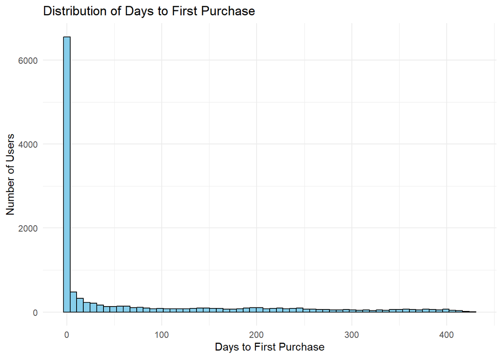

```r
# Visualize the distribution with a histogram
ggplot(days_to_first_purchase, aes(x = Days_Till_First_Purchase)) +
  geom_histogram(binwidth = 7, fill = "skyblue", color = "black") +
  labs(
    title = "Distribution of Days to First Purchase",
    x = "Days to First Purchase",
    y = "Number of Users"
  ) +
  theme_minimal()
```

## Insights

- From the visualization, majority of users make their first purchase within the same week of registration (each bar represents 1 week).
- The histogram shows a strong right-skewed distribution, which flattens out after the first few bins, with same but non-zero counts extending to 424 days (14 months).